# H06 daily metrics — exploratory temporal production

H02-aligned 30-minute arithmetic-mean melEDI GAMM with working AR(1)

Published

August 11, 2026

**NoteAnswer in brief**

The exploratory H02-aligned GAMM found time-varying associations between the 30-minute arithmetic-mean melEDI profile and each recorded day-level context. All four near-eye whole-function tests remained below 0.001 after Benjamini–Hochberg adjustment across the four prespecified tests. These are associations on the fitted transformed scale, not daily-metric results, raw arithmetic-mean effects, causal effects, or health outcomes.

Five of six prespecified frames passed the production diagnostics. The paired chest frame failed the prespecified residual scale-pattern rule and was not used for association extraction. Every displayed band is a **pointwise 95% confidence interval**. No simultaneous interval was constructed or described.

# 1 Scope and estimand

This is a separate exploratory amendment to the preregistration-aligned participant-day analysis. It uses one supported 30-minute bin per row and asks how the transformed local-time profile varies with Work/Free day, the daily Sedentary/Active label, and previous-night sleep duration. It is also separate from the approved hourly H06 analysis.

Let $Y$ be a supported bin’s 30-minute arithmetic mean melEDI in lx. The model response is

$$Z = \log_{10}\!\left(Y + 0.1\ \mathrm{lx}\right).$$

The fitted target is $E[Z \mid \text{local time, context, site, participant, participant-day}]$. The reader-facing inverse transform $\max(0, 10^{\eta} - 0.1)$ lx is geometric-mean-like for $Y+0.1$ and conditional-median-like under the Gaussian log model. It is **not** the raw-scale arithmetic expectation $E[Y]$.

# 2 Exact H02-aligned model

**Show audit R code**

```r
response ~
  s(time_hour, bs = "cc", k = 12) +
  s(time_hour, work_free_day, bs = "sz", k = 12) +
  s(time_hour, activity_status, bs = "sz", k = 12) +
  s(time_hour, by = sleep_between_h, k = 12) +
  s(time_hour, by = sleep_within_h, k = 12) +
  s(time_hour, site, bs = "sz", k = 12) +
  s(time_hour, participant, bs = "fs", k = 10) +
  s(participant_day, bs = "re")
```

```
response ~ s(time_hour, bs = "cc", k = 12) + s(time_hour, work_free_day,
    bs = "sz", k = 12) + s(time_hour, activity_status, bs = "sz",
    k = 12) + s(time_hour, by = sleep_between_h, k = 12) + s(time_hour,
    by = sleep_within_h, k = 12) + s(time_hour, site, bs = "sz",
    k = 12) + s(time_hour, participant, bs = "fs", k = 10) +
    s(participant_day, bs = "re")
```

Only the global clock smooth is cyclic. Every fitted `sz`, `fs`, and sleep smooth has `xt = NULL`; their time marginals use mgcv’s default thin-plate basis. The Gaussian identity-link model used fREML, `discrete = TRUE`, one R thread, 0/24 global knots, and H02’s audited true-time sequence boundaries.

The working AR(1) coefficient was re-estimated for each H06_daily frame. The identical full formula was first fitted with $\rho=0$; response residuals from true-time-contiguous pairs gave the lag-1 estimate, clamped to $[-0.95,0.95]$, and the formula was refitted with that fixed value. No H02 numerical $\rho$ was copied.

Previous-night sleep was decomposed within each exact fitted frame into the participant mean across equally weighted days and the day’s deviation from that mean. The participant means were centred on an equally participant-weighted grand mean. Thus the two sleep functions distinguish between-participant from within-participant associations.

# 3 Exact fitted samples

Table 1: Exact samples and frame-specific working AR(1) coefficients.

| Dataset | Placement | Sample | 30-min bins | Participant-days | Participants | Sites | Exact zeros | Fixed rho | Verdict |
| --- | --- | --- | --- | --- | --- | --- | --- | --- | --- |
| Primary dataset | Near eye | All available | 33,057 | 715 | 137 | 9 | 10,225 | 0.579 | Acceptable |
| Primary dataset | Chest | All available | 36,558 | 789 | 149 | 8 | 11,703 | 0.570 | Acceptable |
| Primary dataset | Near eye | Paired/common | 25,583 | 553 | 109 | 8 | 8,114 | 0.579 | Acceptable |
| Primary dataset | Chest | Paired/common | 25,583 | 553 | 109 | 8 | 8,321 | 0.561 | Not acceptable |
| Gap-timing-unaware dataset | Near eye | All available | 32,969 | 710 | 137 | 9 | 10,172 | 0.576 | Acceptable |
| Gap-timing-unaware dataset | Chest | All available | 36,404 | 782 | 149 | 8 | 11,631 | 0.564 | Acceptable |

# 4 Near-eye association functions

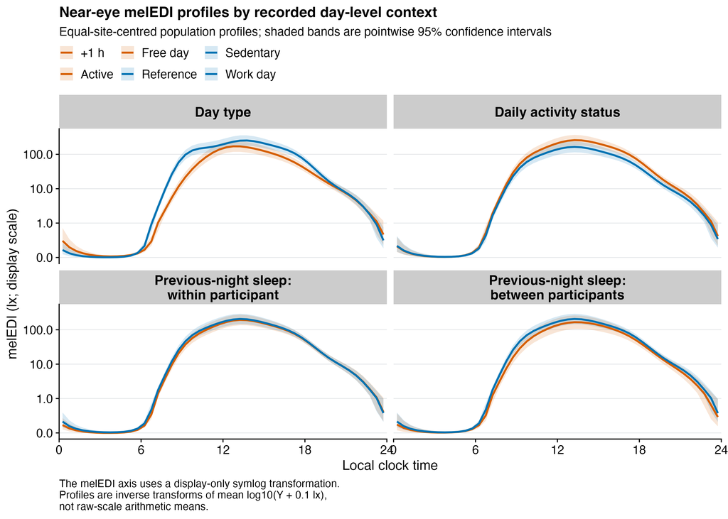

Figure 1: Equal-site-centred near-eye melEDI profiles by recorded context. Bands are pointwise 95% confidence intervals.

The melEDI display axis uses `LightLogR::symlog_trans(base = 10, thr = 1, scale = 1)` only for reader-facing visualization. Source values and model responses remain untransformed beyond the explicitly fitted $\log_{10}(Y+0.1)$ response.

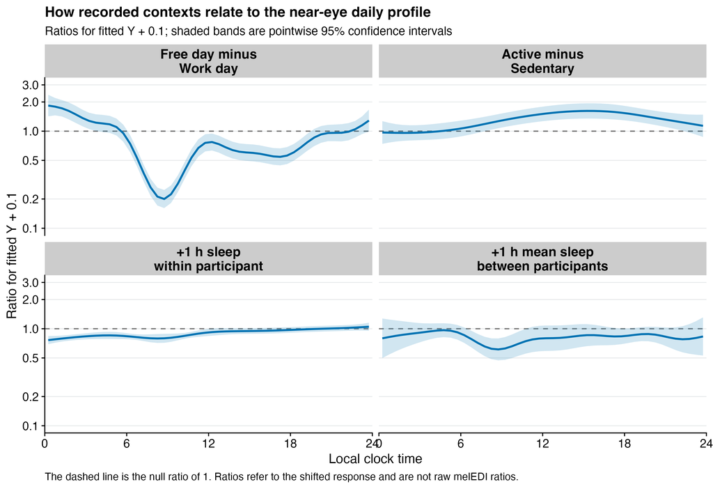

Figure 2: Near-eye context-association functions as ratios for the shifted response Y + 0.1 lx. Bands are pointwise 95% confidence intervals.

Table 2: Strongest fitted association on the shifted-response ratio scale.

| Estimand | Local time | Ratio for Y + 0.1 | Pointwise 95% CI |
| --- | --- | --- | --- |
| Free day minus Work day | 08:45 | 0.20 | 0.16 to 0.25 |
| Active minus Sedentary | 15:15 | 1.62 | 1.35 to 1.94 |
| +1 h previous-night sleep within participant | 00:15 | 0.76 | 0.69 to 0.84 |
| +1 h participant-mean previous-night sleep between participants | 08:45 | 0.61 | 0.47 to 0.79 |

For the primary near-eye fit, the Free-day/Work-day shifted-response ratio was lowest at 08:45 (0.20) and reached 1.84 after midnight. The Active/Sedentary ratio reached 1.62 at 15:15. One hour greater sleep within participant was associated most strongly with a ratio of 0.76 at 00:15; the between-participant sleep ratio was lowest at 08:45 (0.61). These summaries describe fitted associations, not exposure effects caused by the contexts.

# 5 Whole-function tests and multiplicity

Table 3: Exploratory whole-function tests and their prespecified four-test BH adjustment.

| Dataset | Estimand | Raw p | BH-adjusted p<sup>1</sup> | BH decision |
| --- | --- | --- | --- | --- |
| Primary dataset | Free day minus Work day | <0.001 | <0.001 | Retained |
| Primary dataset | Active minus Sedentary | <0.001 | <0.001 | Retained |
| Primary dataset | +1 h previous-night sleep within participant | <0.001 | <0.001 | Retained |
| Primary dataset | +1 h participant-mean previous-night sleep between participants | <0.001 | <0.001 | Retained |
| Gap-timing-unaware dataset | Free day minus Work day | <0.001 | <0.001 | Retained |
| Gap-timing-unaware dataset | Active minus Sedentary | <0.001 | <0.001 | Retained |
| Gap-timing-unaware dataset | +1 h previous-night sleep within participant | <0.001 | <0.001 | Retained |
| Gap-timing-unaware dataset | +1 h participant-mean previous-night sleep between participants | <0.001 | <0.001 | Retained |

<sup>1</sup> Bold denotes retention under the explicitly labelled four-test BH rule. One mgcv approximate p-value was slightly negative from floating-point evaluation; it is preserved in source data and clamped to zero only for BH calculation and display.

The two BH families are separate: one for the four primary near-eye tests and one for the four gap-timing-unaware near-eye tests. Chest and paired/common frames are estimation-only complements. Neither family is combined with the 15 daily-metric families.

# 6 Placement and dataset checks

The all-available chest fit was acceptable, and the paired/common near-eye fit was acceptable. The paired/common chest fit was not acceptable because the absolute-residual/fitted Spearman correlation was 0.313, above the prespecified 0.300 limit. Its model object is retained for provenance, but no context function, confidence interval, or p-value was inspected or extracted.

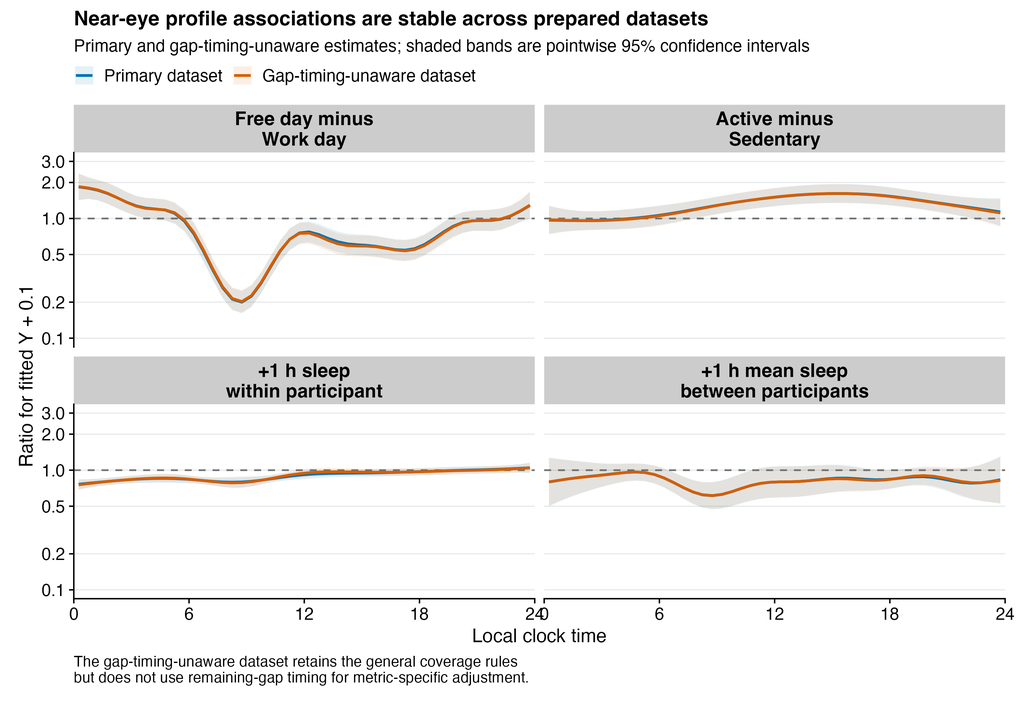

Figure 3: Primary and gap-timing-unaware near-eye association functions. Bands are pointwise 95% confidence intervals.

The maximum absolute difference between the primary and gap-timing-unaware near-eye ratio curves was below 0.031 for every function. This is dataset stability for the exploratory fitted functions, not numerical equivalence with the preregistration-aligned participant-day or approved hourly H06 estimands.

# 7 Diagnostic assessment

Five fitted frames met the prespecified frame, formula, convergence, basis, residual, temporal-dependence, fixed-term identifiability, and cyclic-closure rules. All six models converged without fitting warnings. The primary near-eye residual Q–Q correlation was 0.965, its absolute-residual/fitted Spearman correlation was 0.293, final pooled lag-1 correlation was 0.090, and the largest absolute site lag-1 correlation was 0.159.

The smoothing Hessian’s smallest relative eigenvalue in the primary near-eye fit was $-1.95\times 10^{-15}$, within disclosed floating-point tolerance. The retained global `k = 12` smooth had acceptable capacity after the bounded `k = 16` work/free sensitivity already documented in the reconciliation report.

Influence and site-deletion stability remain **withheld**, not passed. mgcv’s BAM object did not provide the required hat diagonal, and a deletion-refit batch was outside the approved compute scope. Accordingly, the time-varying associations may be reported as exploratory, but no site-deletion robustness claim is made.

# 8 Reproducibility and production closure

The six frame RDS files, six final BAM objects, diagnostics, pointwise source data, tables, three figures, alt text, readability QA, and stage-specific SHA-256 manifests are confined to H06_daily-owned paths. The figures were exported at 170 mm with PNG, PDF, and SVG versions; all have paired source-data CSVs and passed clipping, wrapping, panel-balance, and final-size legibility checks.

This report implements the author’s H06-D-G2P-H02 approval with the explicit pointwise-only amendment. It does not request website integration, authorize a simultaneous interval, authorize a deletion-refit batch, replace the standalone daily-metric report, or transfer any estimate to the approved hourly H06 analysis.